# Calibration of a ball drop model

Pierre Barbillon

# 1 Requirements

We need theses packages

```r
library(readxl) # for reading xl files
library(ggplot2) # for figures
library(CaliCo) # calibration package
library(RobustCalibration) # another calibration package
library(DiceDesign) # package for numerical design of experiments
library(DiceKriging) # package for computing Gaussian process Emulator
```

We load these home-made functions that are the computer models to calibrate

```r
source("functions.R")
```

We load some data about ball dropping. The data are used in (Silva et al. 2020) can be found on the github [repo](https://github.com/briandesilva/discovery-of-physics-from-data/tree/master).

```r
# the sheet number correspond to the type of ball (see the xl file)
don=read_xlsx("Ball_drops_data.xls",sheet = 5)
names(don)=c("drop","time","Height","Velocity")
don$drop=as.factor(don$drop)
```

We start with a plot

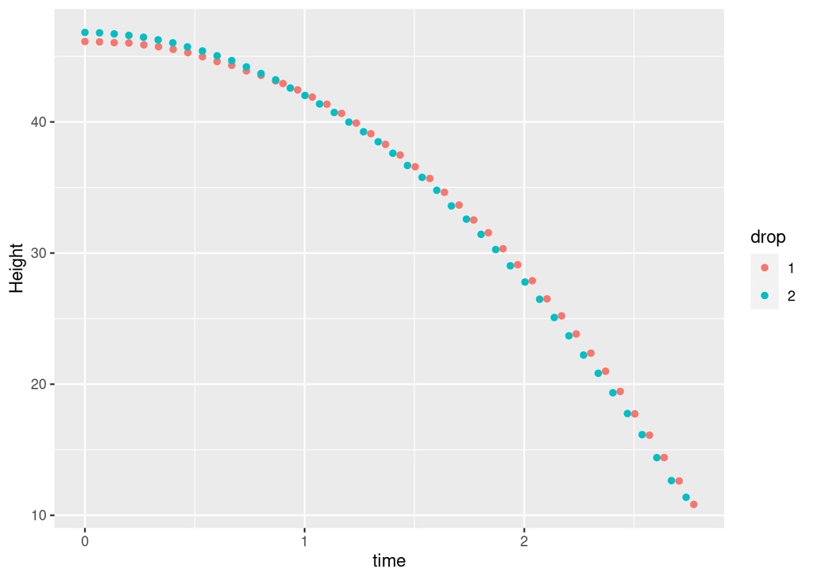

```r
ggplot(don,aes(x=time,y=Height,col=drop))+geom_point()
```

# 2 Simple calibration

We’ll keep the data from the first drop.

```r
don1=don[don$drop==1,]
```

We consider the model (compute code) that provides the height of the ball as a function of time $x=t$ and with two parameters to calibrate $\theta=(g,h_0)$ the gravity constant and the initial height.
$$(x,\theta)\mapsto
h=f(x,\theta)$$
We set the calibration with `CaliCo` under *model 1* according to (Carmassi et al. 2019) terminology:

```r
model1 <- model(balldropg,X=don1$time,Yexp = don1$Height,"model1")
print(model1)
```

```
Call:
[1] "model1"

With the function:
function (t, theta)
{
    g = theta[1]
    h0 = theta[2]
    h = -g * 0.5 * t^2 + h0
    h[h < 0] = 0
    return(h)
}

No surrogate is selected

No discrepancy is added
```

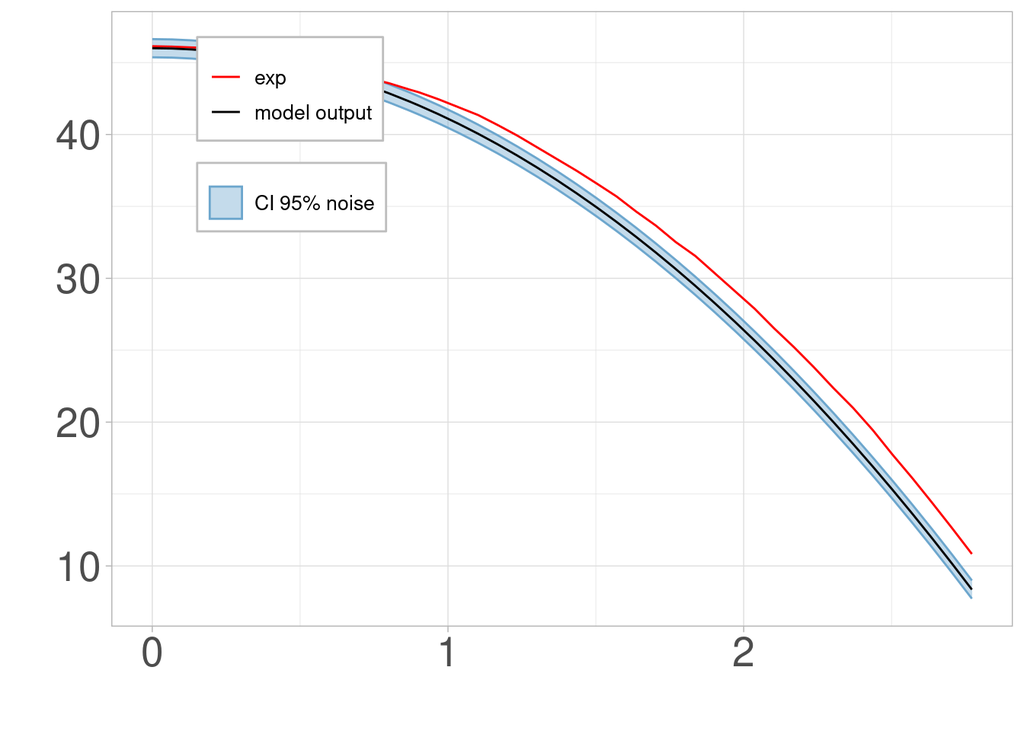

```r
# we provide some parameters to have a plot
model1 %<% list(theta=c(9.8,46),var=1e-1)
model1$plot(x=don1$time)
```

We can choose the prior distributions on the two parameters in $\theta$ and on the observational variance (or measurement error):

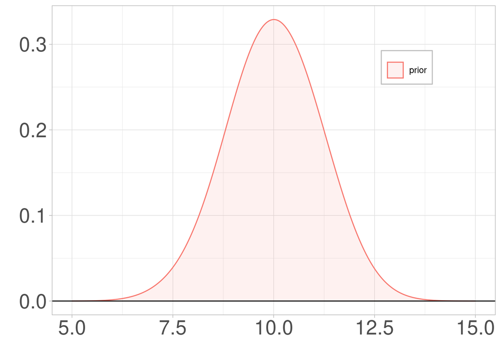

```r
opt.prior <- list(c(10,1),c(45,5),c(1e-2,1e-0))
type.prior <- c(rep("gaussian",2),"unif")
pr1 <- prior(type.prior,opt.prior)
plot(pr1$Prior1)
```

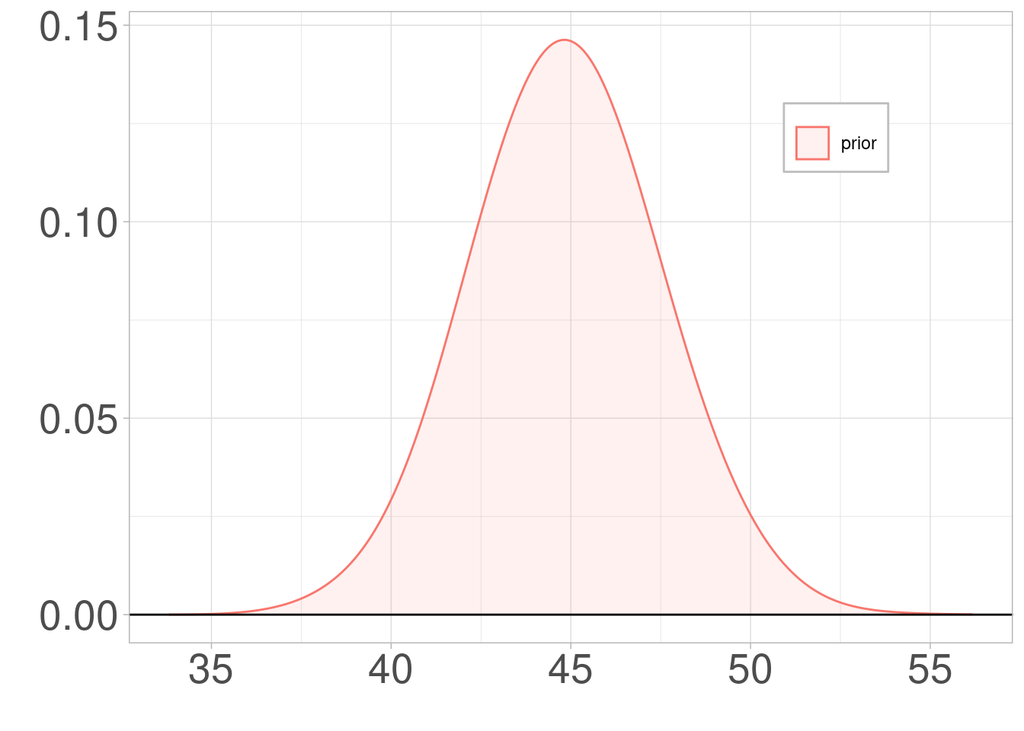

```r
plot(pr1$Prior2)
```

We can then run the calibration and have a look at the results:

```r
opt.estim = list(Ngibbs=10000,Nmh=10000,thetaInit=c(9.8,45,1e-1),
                 r=c(0.1,0.1,.1),sig=(diag(c(0.25,1,1e-1)*.3))^2,Nchains=1,burnIn=2000)
mdfit1 <- calibrate(model1,pr1,opt.estim)
```

```r
print(mdfit1)
```

```
Call:

With the function:
function (t, theta)
{
    g = theta[1]
    h0 = theta[2]
    h = -g * 0.5 * t^2 + h0
    h[h < 0] = 0
    return(h)
}
<bytecode: 0x56168fa094d0>

Selected model : model1

Acceptation rate of the Metropolis within Gibbs algorithm:
[1] "38.08%" "24.03%" "28.6%"

Acceptation rate of the Metropolis Hastings algorithm:
[1] "32.17%"

Maximum a posteriori:
[1]  9.2204626 46.7244840  0.1101157

Mean a posteriori:
[1]  9.1313193 46.5504446  0.1039487
```

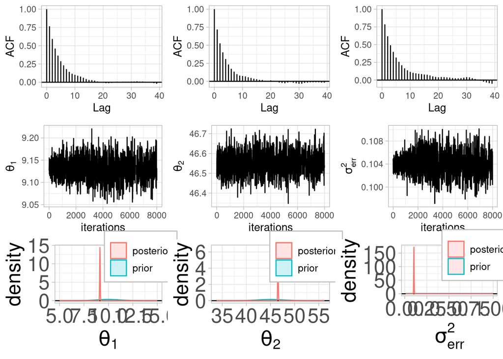

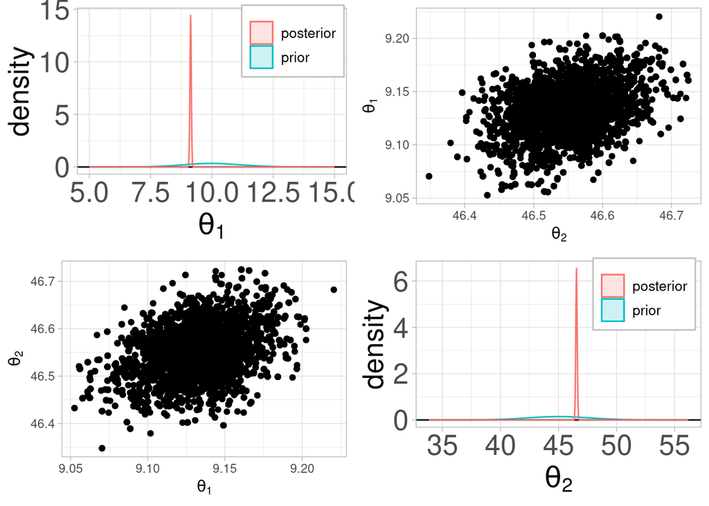

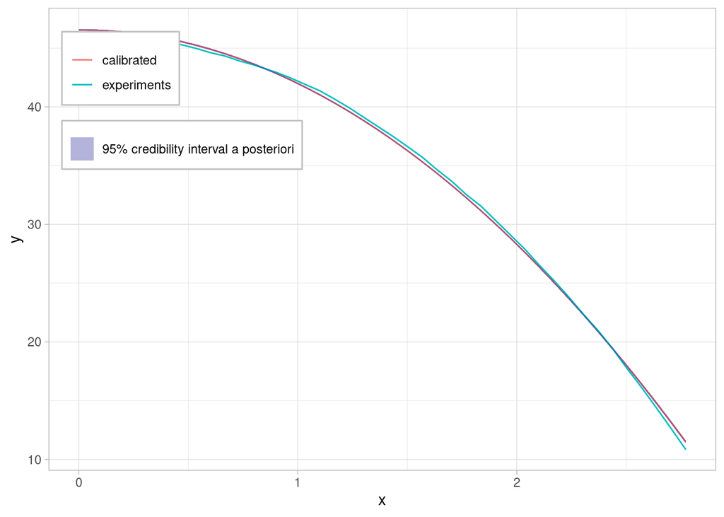

```r
plot(mdfit1,don1$time)
```

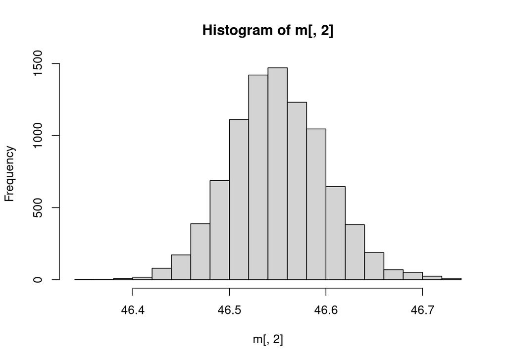

```r
m = mdfit1$output$out$THETA[-(1:1000),]
hist(m[,2])
```

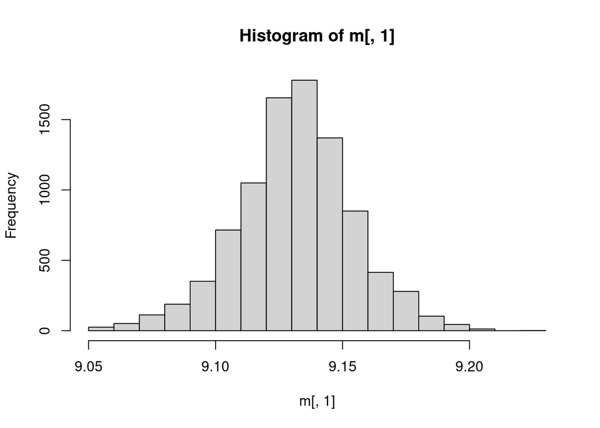

```r
hist(m[,1])
```

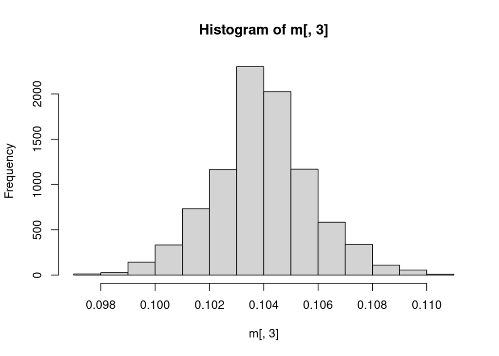

```r
hist(m[,3])
```

By using the MAP for $\theta$, we can obtain predictions and compute the MSE.

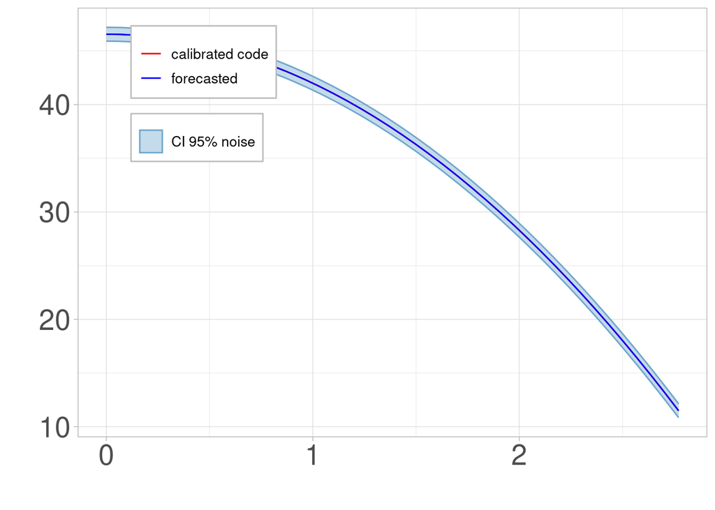

```r
ypred = forecast(mdfit1,don1$time)
plot(ypred,don1$time)
```

```r
mean((ypred$y.new.pred$y-don1$Height)^2)
```

```
[1] 0.09271534
```

In order to test the prediction and the coverage rate, we can use cross validation

```r
mdfitCV <- calibrate(model1,pr1,
                     opt.estim = list(Ngibbs=1000,
                                      Nmh=5000,
                                      thetaInit=c(9.8,45,1e-1),
                                r=c(0.1,0.1,.1),sig=(diag(c(0.25,1,1e-1)*.3))^2,Nchains=1,burnIn=2000),
                     opt.valid = list(type.valid="loo",
                                      nCV=50))
```

```r
print(mdfitCV)
```

```
Call:

With the function:
function (t, theta)
{
    g = theta[1]
    h0 = theta[2]
    h = -g * 0.5 * t^2 + h0
    h[h < 0] = 0
    return(h)
}
<bytecode: 0x55a30dead190>

Selected model : model1

Acceptation rate of the Metropolis within Gibbs algorithm:
[1] "63.5%" "17.3%" "20.5%"

Acceptation rate of the Metropolis Hastings algorithm:
[1] "59.76%"

Maximum a posteriori:
[1]  9.2636016 46.7784532  0.1069267

Mean a posteriori:
[1]  9.1392385 46.5589027  0.1019072


Cross validation:
 Method: loo
  Predicted     Real       Error
1  43.13085 43.13187 0.001017761
2  41.67053 41.89956 0.229031427
3  31.15424 31.54828 0.394039020
4  23.69923 23.83016 0.130929637
5  19.42488 19.44317 0.018283849
6  39.59713 39.91591 0.318785698

RMSE: [1] 0.506053

Cover rate:
[1] "100%"
```

```r
mdfitCV$ResultsCV
```

```
   Predicted     Real        Error
1   43.13085 43.13187 0.0010177610
2   41.67053 41.89956 0.2290314272
3   31.15424 31.54828 0.3940390202
4   23.69923 23.83016 0.1309296366
5   19.42488 19.44317 0.0182838492
6   39.59713 39.91591 0.3187856982
7   46.55498 46.10805 0.4469310920
8   27.59080 27.89219 0.3013968836
9   16.38248 16.11230 0.2701750090
10  46.52468 46.13628 0.3883948585
11  11.41430 10.83166 0.5826354628
12  32.23738 32.52318 0.2857968186
13  42.26879 42.44439 0.1756022810
14  44.10040 43.89717 0.2032301222
```

[output cut: 36 more lines]

# 3 Calibration with discrepancy

We propose then to add a discrepancy term in the model which corresponds to *model 3* according to (Carmassi et al. 2019)’s terminology.

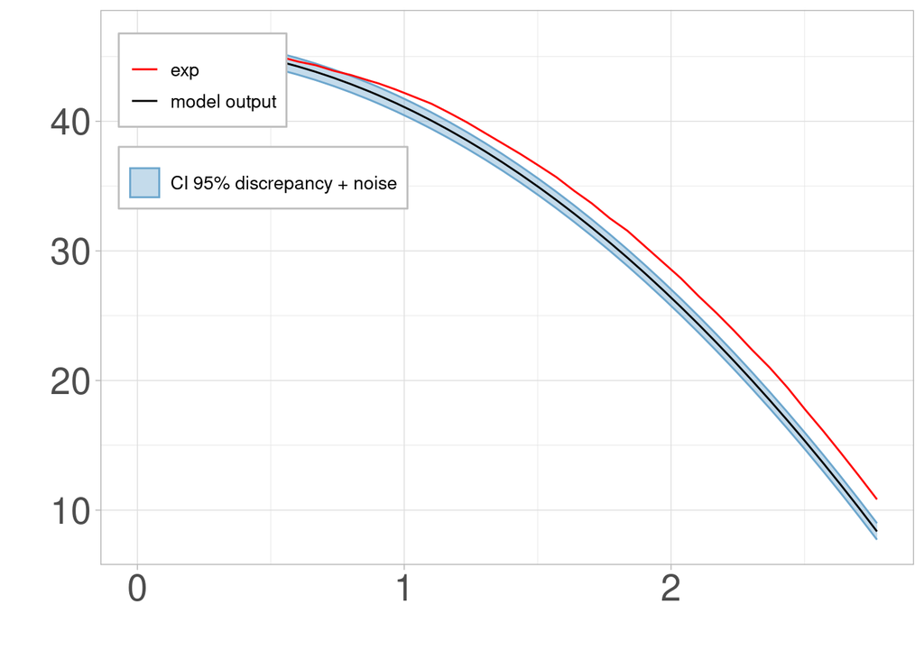

```r
model3 <- model(balldropg,don1$time,don1$Height,"model3",
                opt.disc = list(kernel.type="gauss"))
model3 %<% list(theta=c(9.8,46),thetaD=c(1e-1,1),var=1e-3)
plot(model3,don1$time)
```

```r
type.prior <- c(rep("gaussian",2),"unif","unif","unif")
opt.prior <- list(c(10,1),c(40,5),c(1e-2,1e-0),c(0,2),c(1e-2,1e-0))
pr2 <- prior(type.prior,opt.prior)

opt.estim2=list(Ngibbs=1e4,Nmh=1e4,thetaInit=c(10,46,1e-1,0.5,1e-1),
                r=c(0.1,0.1),sig=(diag(c(1,1,1e-1,.5,1e-1)*.2))^2,Nchains=1,burnIn=2000)
```

```r
mdfit3 <- calibrate(model3,pr2,opt.estim2)
```

```
[1] "The computational time might be long to get the output plot"
```

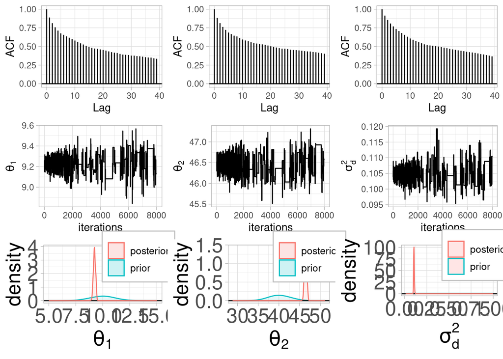

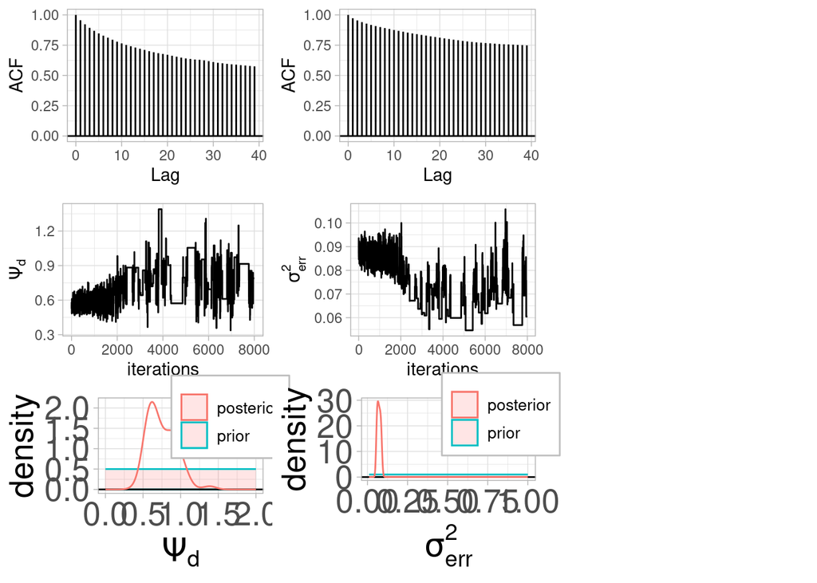

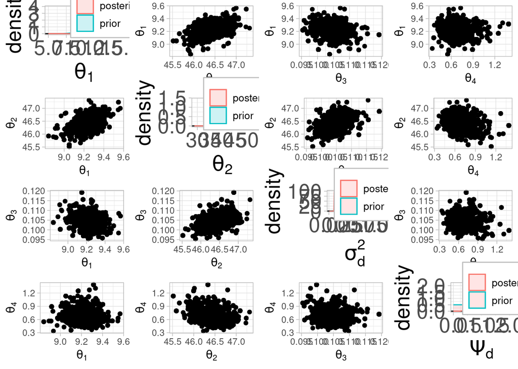

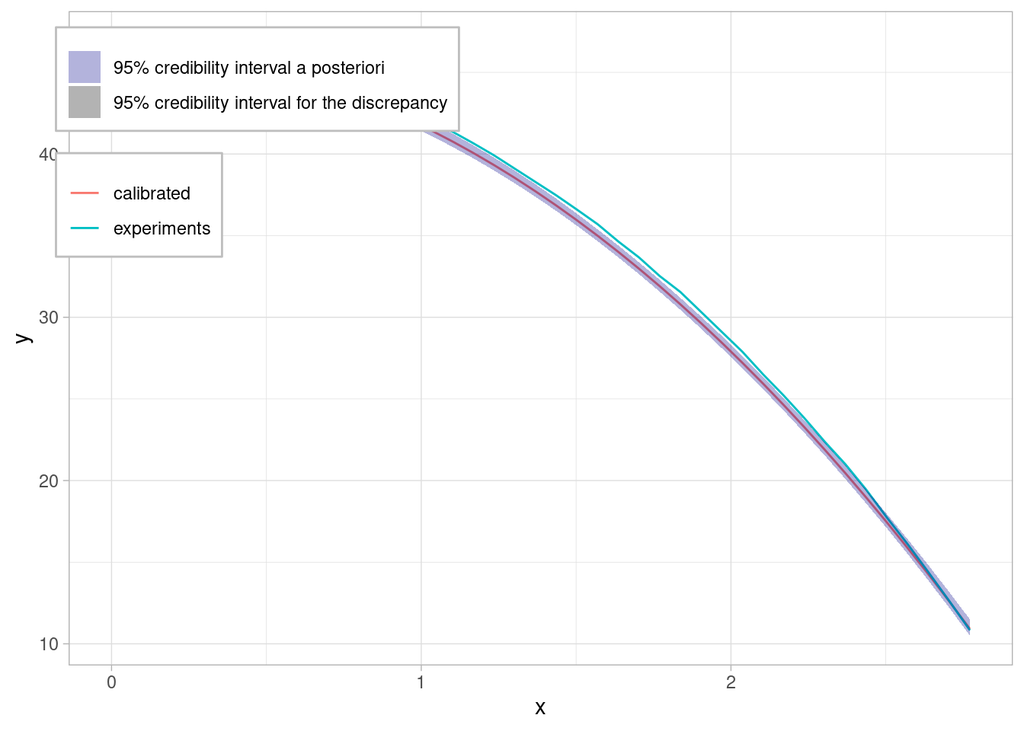

```r
plot(mdfit3,don1$time)
```

```r
print(mdfit3)
```

```
Call:

With the function:
function (t, theta)
{
    g = theta[1]
    h0 = theta[2]
    h = -g * 0.5 * t^2 + h0
    h[h < 0] = 0
    return(h)
}
<bytecode: 0x56157fac3c98>

Selected model : model3

Acceptation rate of the Metropolis within Gibbs algorithm:
[1] "65.66%" "45.17%" "51.22%" "53.36%" "54.74%"

Acceptation rate of the Metropolis Hastings algorithm:
[1] "27.8%"

Maximum a posteriori:
[1]  9.5662782 47.3139099  0.1192344  1.3893981  0.1057993

Mean a posteriori:
[1]  9.22878566 46.43685325  0.10479450  0.74960623  0.07172582
```

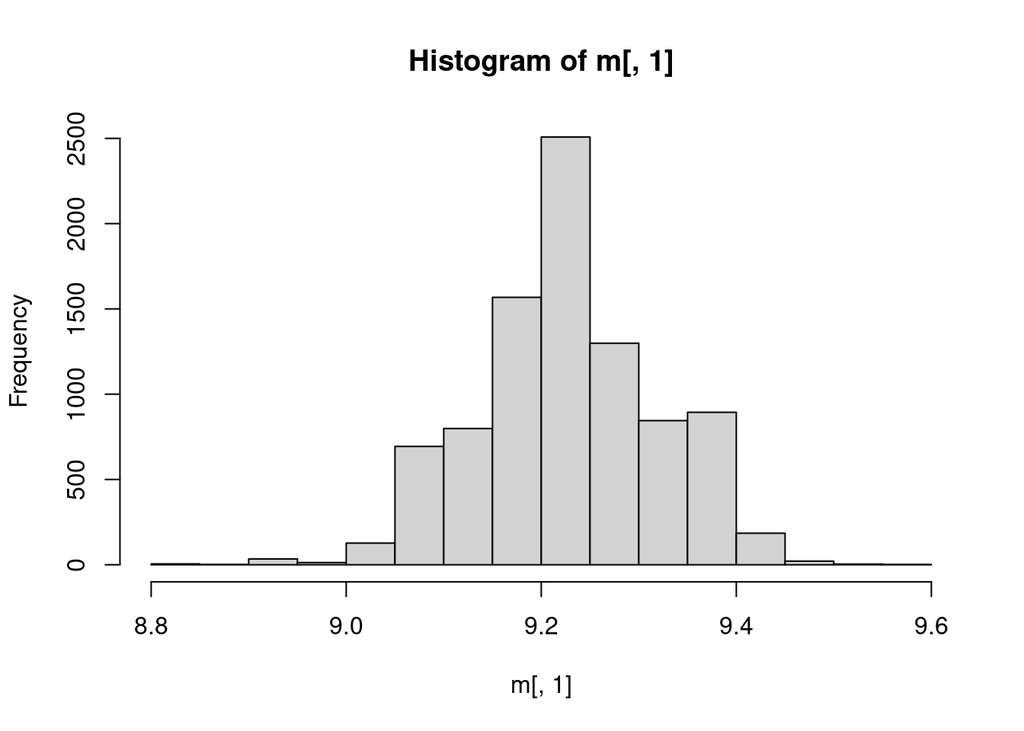

```r
m = mdfit3$output$out$THETA[-(1:1000),]
hist(m[,1])
```

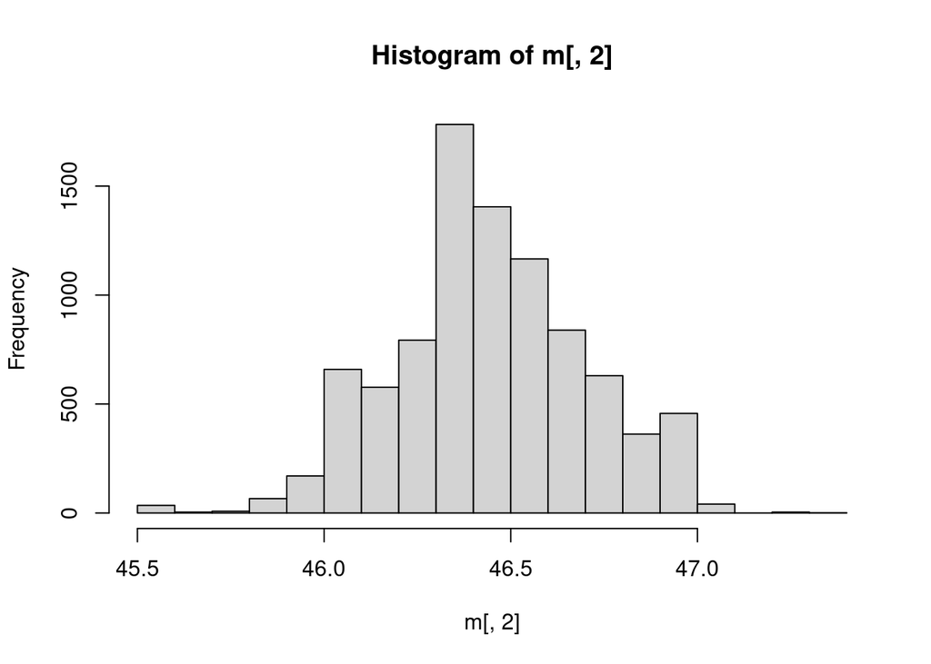

```r
hist(m[,2])
```

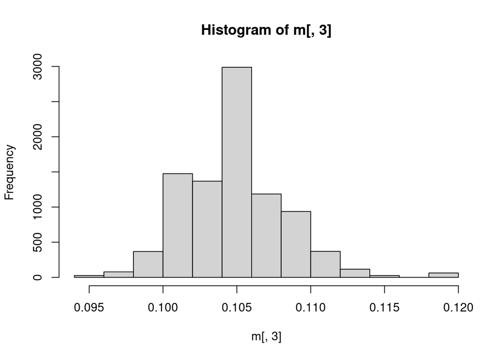

```r
hist(m[,3])
```

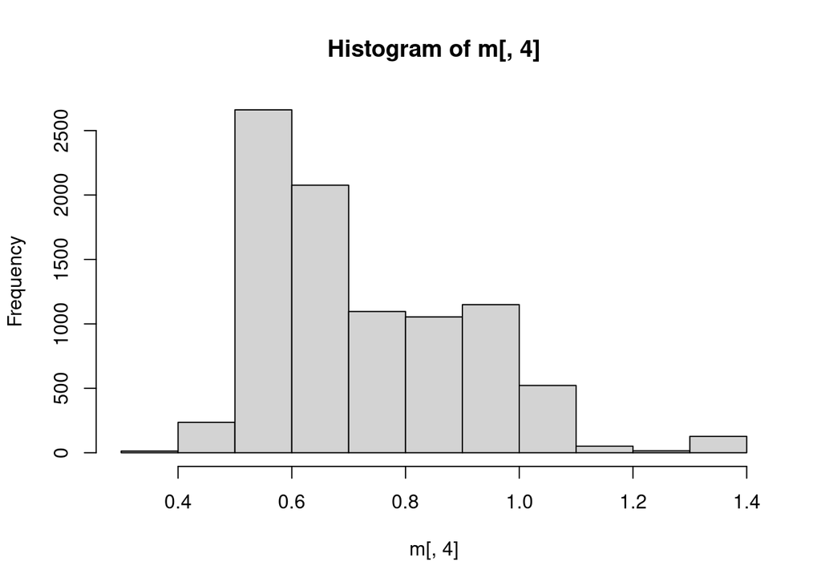

```r
hist(m[,4])
```

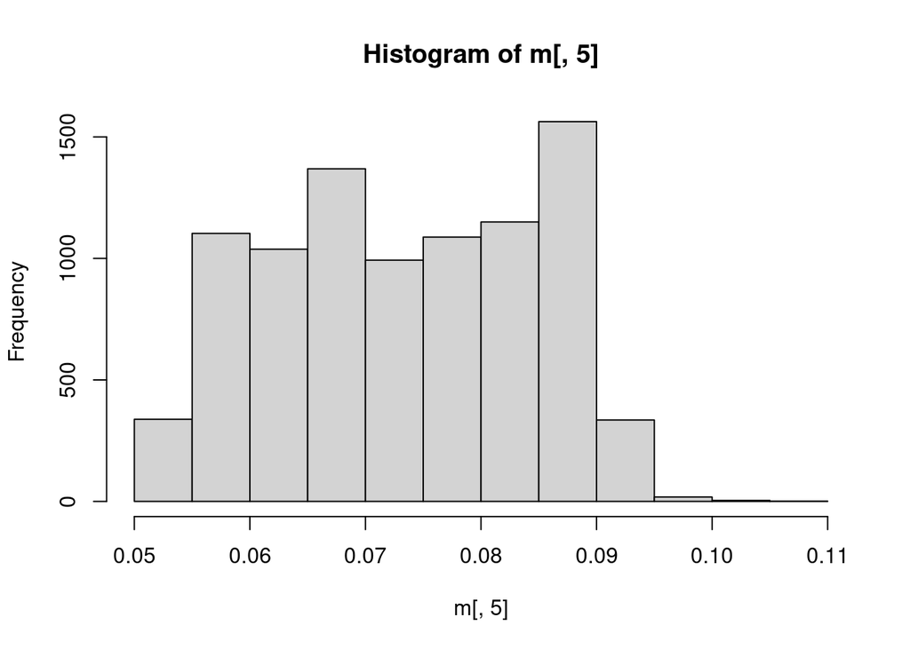

```r
hist(m[,5])
```

By using the MAP for $\theta$, we can obtain predictions and compute the MSE.

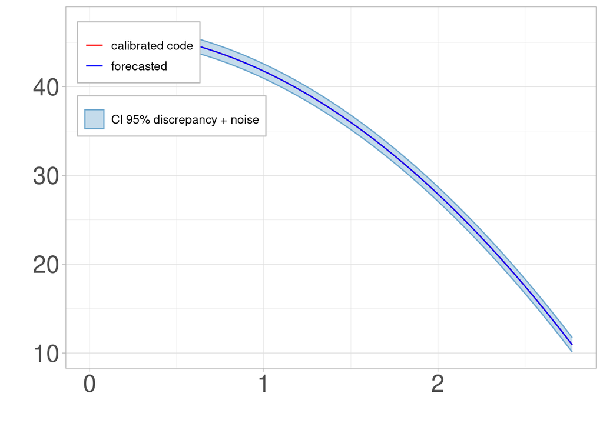

```r
ypred = forecast(mdfit3,don1$time)
plot(ypred,don1$time)
```

```r
mean((ypred$y.new.pred$y-don1$Height)^2)
```

```
[1] 0.208324
```

# 4 Time-consuming code

We assume here that the code modeling the ball drop is time-consuming. We make recourse to a Gaussian Process Emulator. We first consider that there is no discrepancy. Hence, we are in the framework of *model 2*.

```r
# bounds on theta for the GP emulator
binf = c(8,40)
bsup = c(11,50)
# design of experiments and limited number of evaluations to the computer code
ndesign=10
DOE <- maximinSA_LHS(lhsDesign(ndesign,3)$design)$design
DOE <- unscale(DOE,c(min(don1$time),binf),c(max(don1$time),bsup))
Ysim <- balldropg(DOE[1,1],DOE[1,2:3])
for (i in 2:ndesign){Ysim <- c(Ysim,balldropg(DOE[i,1],DOE[i,2:3]))}
```

# References

Carmassi, Mathieu, Pierre Barbillon, Matthieu Chiodetti, Merlin Keller, and Eric Parent. 2019. “Bayesian Calibration of a Numerical Code for Prediction.” *Journal de La Société Française de Statistique* 160 (1): 1–30. http://www.numdam.org/item/JSFS_2019__160_1_1_0/.

Silva, Brian M de, David M Higdon, Steven L Brunton, and J Nathan Kutz. 2020. “Discovery of Physics from Data: Universal Laws and Discrepancies.” *Frontiers in Artificial Intelligence* 3: 25.